# zagadnienie_wlasne_1

## Zagadnienie własne

Szukamy wartości własnej $\lambda$ i wektora własnego $\mathbb{x}$ macierzy $\mathbb{A}$ $n\times n$ takich, że

\begin{equation} \label{zw1} \mathbb{Ax}=\lambda \mathbb{x} \end{equation}

Równanie (\ref{zw1}) można przepisać w postaci

\begin{equation} \label{zw2} \left(\mathbb{A}-\lambda \mathbb{I} \right)\mathbb{x}=\mathbb{0} \end{equation}

z którego wynika, że mamy do czynienia z jednorodnym układem równań liniowych. Nietrywialne rozwiązanie układu (\ref{zw2}) istnieje, gdy zeruje się wyznacznik

\begin{equation} \label{zw3} \left|\mathbb{A}-\lambda \mathbb{I} \right|=0 \end{equation}

Rozwinięcie tego wyznacznika prowadzi do wielomianu charakterystycznego macierzy $\mathbb{A}$

\begin{equation} \label{zw4} \left|\mathbb{A}-\lambda \mathbb{I} \right|= a_0+a_1\lambda +a_2\lambda^2+\cdots+a_n\lambda^n=0, \end{equation}

którego pierwiastki są wartościami własnymi macierzy $\mathbb{A}$

#### Przykład

\begin{equation} \mathbb{A}=\left(\begin{matrix} 2 & -1 & 0\\ -1 & 2 & -1\\ 0 & -1 & 2 \end{matrix}\right) \end{equation}

Wielomian charaktereystyczny tej macierzy

\begin{equation} \label{wchp} \left|\mathbb{A}-\lambda \mathbb{I} \right|= \left|\begin{matrix} 2-\lambda & -1 & 0\\ -1 & 2-\lambda & -1\\ 0 & -1 & 2 -\lambda \end{matrix}\right|=\left(2-\lambda\right)\left[\left(2-\lambda\right)^2 -1 \right]-\left(2-\lambda\right)= \left(2-\lambda\right)\left[\left(2-\lambda\right)^2 -2 \right]=0 \end{equation}

Łatwo obliczyć wartości własne $\mathbb{A}$, czyli pierwiastki równania (\ref{wchp})

$\lambda_1=2, \lambda_2=2+\sqrt{2}, \lambda_3=2-\sqrt{2} $.

Wektor własny $\mathbb{x}_i$ obliczymy podstawiając $\lambda_i$ do (\ref{zw2}) i rozwiązując ten układ równań, np. dla $\lambda_1$ otrzymujemy

\begin{equation} \left(\begin{matrix} 0 & -1 & 0\\ -1 & 0 & -1\\ 0 & -1 & 0 \end{matrix}\right) \left(\begin{matrix} x_{11}\\ x_{21}\\ x_{31} \end{matrix}\right)= \left(\begin{matrix} 0\\ 0\\ 0 \end{matrix}\right) \end{equation}

Rozwiązaniem jest $x_{21}=0, \;\; x_{31}=-x_{11}$.

\begin{equation} \mathbb{x}_1= \left(\begin{matrix} 1\\ 0\\ -1 \end{matrix}\right) \end{equation}

Postępując podobnie obliczymy wektory własne $\mathbb{x}_2$ i $\mathbb{x}_3$

\begin{equation} \mathbb{x}_2= \left(\begin{matrix} 1\\ -\sqrt{2}\\ 1 \end{matrix}\right), \;\; \mathbb{x}_3= \left(\begin{matrix} 1\\ \sqrt{2}\\ 1 \end{matrix}\right) \end{equation}

Ponieważ wektor własny nie jest jednoznacznie określony to zwykle normuje się go do jedynki. Unormowane wektory mają postać

\begin{equation} \mathbb{x}_1=\frac{\sqrt{2}}{2} \left(\begin{matrix} 1\\ 0\\ -1 \end{matrix}\right), \;\; \mathbb{x}_2=\frac{1}{2} \left(\begin{matrix} 1\\ -\sqrt{2}\\ 1 \end{matrix}\right), \;\; \mathbb{x}_3=\frac{1}{2} \left(\begin{matrix} 1\\ \sqrt{2}\\ 1 \end{matrix}\right) \end{equation}

W ogólnym przypadku, wartości własnych nie oblicza się z wielomianu charakterystycznego lecz stosuje sie bardziej efektywne metody, które przedstawimy później

### Funkcje do obliczania wartości i wektorów własnych

W sicipy.linalg mamy kilka funkcji do obliczania wartości i wektorów własnych.

Gdy mamy do czynienia z symetrycznymi macierzami, $A_{i,j}=A_{j,i},\;\; i,j=0,1,\dots,n-1$, których wartości własne są rzeczywiste, to możemy użyć funkcji scipy.linalg.eigh().

https://docs.scipy.org/doc/scipy/reference/generated/scipy.linalg.eigh.html#scipy.linalg.eigh

Przykład

\begin{equation} \mathbb{A}_1=\left(\begin{matrix} 2 & 1 & 0 & 1\\ 1 & 2 & 1 & 0\\ 0 & 1 & 2 & 1\\ 1 & 0 & 1 & 2 \end{matrix}\right) \end{equation}

```python
from scipy.linalg import eigh
import numpy as np
A1=np.array(
[[ 2,  1,  0,  1],
 [ 1,  2,  1,  0],
 [ 0,  1,  2,  1],
 [ 1,  0,  1,  2]],dtype=float)
w1,v1=eigh(A1)
print("wartości własne")
print(w1)
np.set_printoptions(precision=4)
print("\n wektory własne")
print(v1)
```

```
wartości własne
[2.66453526e-15 2.00000000e+00 2.00000000e+00 4.00000000e+00]

 wektory własne
[[ 5.0000e-01  0.0000e+00  7.0711e-01 -5.0000e-01]
 [-5.0000e-01 -7.0711e-01  4.5756e-16 -5.0000e-01]
 [ 5.0000e-01 -2.8708e-16 -7.0711e-01 -5.0000e-01]
 [-5.0000e-01  7.0711e-01  1.7048e-16 -5.0000e-01]]
```

```python
# Wektory własne A1 - kolumny macierzy v1,  są ortonormalne
# pokażemy to obliczając iloczyny skalarne  wektorów własnych
from scipy import dot
n=4
for i in range(n):
    for k in range(i,n):
        print("%2d  %2d   %12.8f" %(i,k,dot(v1[:,i],v1[:,k])))
```

```
 0   0     1.00000000
 0   1    -0.00000000
 0   2     0.00000000
 0   3    -0.00000000
 1   1     1.00000000
 1   2     0.00000000
 1   3    -0.00000000
 2   2     1.00000000
 2   3     0.00000000
 3   3     1.00000000
```

Dla macierzy niesymetrycznych lub niehermitowskich używamy funkcji scipy.linalg.eig(), która znajduje również zespolone wartości własne.

https://docs.scipy.org/doc/scipy/reference/generated/scipy.linalg.eig.html#scipy.linalg.eig

Przykład 2.

\begin{equation} \mathbb{A}_2=\left(\begin{matrix} 2 & 9 & 0 & 2\\ -1 & 2 & 1 & 0\\ 0 & 0 & 3 & 0\\ 0 & 0 & 1 & -1 \end{matrix}\right) \end{equation}

```python
from scipy.linalg import eig
A2=np.array(
[[ 2,  9,  0,  2],
 [ -1,  2,  1,  0],
 [ 0,  0,  3,  0],
 [ 0,  0,  1,  -1]],dtype=float)

w2,v2=eig(A2)
np.set_printoptions(precision=4)
print("wartości własne")
print(w2)
#wektory własne A2
np.set_printoptions(precision=4)
print("\n wektory własne")
print(v2)
```

```
wartości własne
[ 2.+3.j  2.-3.j -1.+0.j  3.+0.j]

 wektory własne
[[ 0.9487+0.j      0.9487-0.j     -0.3145+0.j      0.6773+0.j    ]
 [ 0.    +0.3162j  0.    -0.3162j -0.1048+0.j      0.0356+0.j    ]
 [ 0.    +0.j      0.    -0.j      0.    +0.j      0.7129+0.j    ]
 [ 0.    +0.j      0.    -0.j      0.9435+0.j      0.1782+0.j    ]]
```

Do obliczania wartości własnych trójdiagonalnych, symetrycznych macierzy służy funkcja eigh_tridiagonal(d,e), której argumentami są diagonalne elementy d i pozadiagonalne e.

https://docs.scipy.org/doc/scipy/reference/generated/scipy.linalg.eigh_tridiagonal.html#scipy.linalg.eigh_tridiagonal

Przykład

\begin{equation} \mathbb{A}_3=\left(\begin{matrix} 4 & -2 & 0 & 0\\ -2 & 4 & -2 & 0\\ 0 & -2 & 4 & -2\\ 0 & 0 & -2 & 4 \end{matrix}\right) \end{equation}

gdzie

\begin{equation} \mathbb{d}=\left(\begin{matrix} 4 & 4 & 4 & 4 \end{matrix}\right) \end{equation}\begin{equation} \mathbb{e}=\left(\begin{matrix} -2 & -2 & -2 \end{matrix}\right) \end{equation}

```python
from scipy.linalg import eigh_tridiagonal

n=4
d=4*np.ones(n)
nd=-2*np.ones(n-1)
w3,v3=eigh_tridiagonal(d,nd)
#pierwsze 3 wartośći własne
print("wartości własne")
print(w3[:3])
#pierwsze 3 wektory własne
print("\n wektory własne")
print(v3[:,:3])
```

```
wartości własne
[0.7639 2.7639 5.2361]

 wektory własne
[[ 0.3717 -0.6015  0.6015]
 [ 0.6015 -0.3717 -0.3717]
 [ 0.6015  0.3717 -0.3717]
 [ 0.3717  0.6015  0.6015]]
```

```python
# Teraz dla macierzy typu A3 o 20x20 składowych
n=20
d=4*np.ones(n)
nd=-2*np.ones(n-1)
w3,v3=eigh_tridiagonal(d,nd)
#pierwsze 3 wartośći własne
print("wartości własne")
print(w3[:3])
```

```
wartości własne
[0.0447 0.1777 0.3961]
```

### Metoda potęgowa

Służy do znalezienia najdalej leżacej od zera wartości własnej macierzy $\mathbb{A}$ i związanego z nią wektora własnego.

Startując z losowego i unormowanego wektora $\mathbb{v}$ ($||\mathbb{v}||=1$) obliczamy nowy wektor

\begin{equation} \label{mpot1} \mathbb{z}=\mathbb{A}\mathbb{v} \end{equation}

oraz jego normę $$ \label{mpot2} n_z=||\mathbb{z}||$$.

Podstawiając za $\mathbb{v}$ unormowany wektor $\mathbb{z}$ $$ \mathbb{v}=\frac{\mathbb{z}}{n_z} $$ powtarzamy czynności (\ref{mpot1}) i (\ref{mpot2}) aż osiągniemy założoną zbieżność.

Wynikiem tych obliczeń jest wartość własna $\lambda=\pm n_z$ oraz wektor własny $\mathbb{v}$. Znak wartości własnej jest ujemny, jeśli podczas iteracji wektor $\mathbb{v}$ zmienia znak.

Zastosujemy teraz tę metodę do znalezienia wartości własnej macierzy $\mathbb{A}_1$

```python
# Power method
from scipy.linalg import norm
n=4
tol=1e-5
#losowy wektor
v=np.random.random(n)
v=v/norm(v)
# iteracyjne obliczanie wektora i wartości własnej macierzy A1
warunek=True
licz=0
while warunek or licz==20:
    vtym=v.copy()
    #nowy wektor
    z=dot(A1,v.T)
    #jego długość
    nz=norm(z)
    # normowanie v
    v=z/nz
    # czy v zmienia znak
    if dot(v,vtym)<0:
        znak=-1
        v=-v    #zmieniamy również znak v, żeby móc sprawdzić zbieżność
    else:
        znak=1
    if norm(v-vtym)<tol:  # warunek zbieżności
        warunek=False
    licz+=1
    print(nz,'    ',v)

print('\n lambda=',znak*nz)
print(v)
```

```
3.656843155637892      [0.4047 0.3473 0.5688 0.6262]
3.9206628145735647      [0.4547 0.4254 0.5384 0.5677]
3.9795071079156945      [0.4781 0.4634 0.5202 0.5349]
3.9948337989779312      [0.4893 0.4819 0.5103 0.5177]
3.9987057338849494      [0.4947 0.491  0.5052 0.5089]
3.999676263259826      [0.4974 0.4955 0.5026 0.5045]
3.9999190551693737      [0.4987 0.4978 0.5013 0.5022]
3.99997976312688      [0.4993 0.4989 0.5007 0.5011]
3.9999949407401263      [0.4997 0.4994 0.5003 0.5006]
3.999998735182432      [0.4998 0.4997 0.5002 0.5003]
3.9999996837954455      [0.4999 0.4999 0.5001 0.5001]
3.9999999209488517      [0.5    0.4999 0.5    0.5001]
3.999999980237212      [0.5 0.5 0.5 0.5]
3.999999995059303      [0.5 0.5 0.5 0.5]
3.999999998764826      [0.5 0.5 0.5 0.5]
3.9999999996912066      [0.5 0.5 0.5 0.5]

 lambda= 3.9999999996912066
[0.5 0.5 0.5 0.5]
```

### Odwrotna metoda potęgowa

Służy do znalezienia wartości własnej leżącej najbliżej zera i opdowiadającego jej wektora własnego. Metoda ta działa podobnie do metody potegowej, z tym że do obliczenia wektora $\mathbb{z}$ równanie (\ref{mpot1}) zastępuje się równaniem

\begin{equation} \label{ompot1} \mathbb{z}=\mathbb{A}^{-1}\mathbb{v} \end{equation}

Czyli, obliczenie $\mathbb{z}$ wymaga rozwiązania układu równań liniowych

\begin{equation} \label{ompot2} \mathbb{A}\mathbb{z}=\mathbb{v} \end{equation}

Układ (\ref{mpot1}) rozwiązujemy metodą LU. Wynikiem obliczeń jest wartość własna $\lambda=\pm \frac{1}{ n_z}$ oraz wektor własny $\mathbb{v}$. Znak wartości własnej jest ujemny, jeśli podczas iteracji wektor $\mathbb{v}$ zmienia znak.

```python
from scipy.linalg import solve
# Inverse power method
n=4
tol=1e-5
#losowy wektor
v=np.random.random(n)
v=v/norm(v)
# iteracyjne obliczanie wektora i wartości własnej macierzy A2
warunek=True
licz=0
while warunek or licz==20:
    vtym=v.copy()
    #nowy wektor
    z=solve(A2,v)
    #jego długość
    nz=norm(z)
    # normowanie v
    v=z/nz
    # czy v zmienia znak
    if dot(v,vtym)<0:
        znak=-1
        v=-v
    else:
        znak=1
    if norm(v-vtym)<tol:
        warunek=False
    licz+=1
    print(znak/nz,'    ',v)

print('\n lambda=',znak/nz)
print(v)
```

```
3.6636202418443227      [-0.3877  0.469   0.5768 -0.545 ]
-1.1048769600219484      [ 0.5282  0.1112 -0.2124 -0.8146]
-1.2547907071264364      [ 0.3433  0.0574  0.0889 -0.9332]
-0.9946543281340093      [ 0.2613  0.1168 -0.0295 -0.9577]
-0.98778561351954      [ 0.335   0.1049  0.0097 -0.9363]
-1.005934339527597      [ 0.3098  0.1037 -0.0033 -0.9451]
-0.9991245245764572      [ 0.3151  0.1052  0.0011 -0.9432]
-0.9999155970263391      [ 3.1440e-01  1.0479e-01 -3.6106e-04 -9.4349e-01]
-1.0000697228661721      [ 3.1455e-01  1.0482e-01  1.2036e-04 -9.4344e-01]
-0.9999935398924658      [ 3.1444e-01  1.0483e-01 -4.0121e-05 -9.4347e-01]
-0.9999938292732907      [ 3.1450e-01  1.0483e-01  1.3374e-05 -9.4345e-01]
-1.0000033315516506      [ 3.1448e-01  1.0483e-01 -4.4579e-06 -9.4346e-01]
-0.9999991382539818      [ 3.1449e-01  1.0483e-01  1.4859e-06 -9.4346e-01]

 lambda= -0.9999991382539818
[ 3.1449e-01  1.0483e-01  1.4859e-06 -9.4346e-01]
```

### Przesuwanie wartości własnych

Jeśli w zagadnieniu własnym macierz $\mathbb{A}$ zastąpimy macierzą

\begin{equation} \label{przesuw1} \mathbb{A}^{*}=\mathbb{A}-s\mathbb{I} \end{equation}

to możemy poprawić zbieżność obliczania wartości własnych $\lambda^{*}$ macierzy $\mathbb{A}^{*}$, np. odwrotną metodą potegową.

Ponieważ $$ \lambda^{*}_i=\lambda_i-s $$ to wybierając s blisko szukanej wartości własnej $s\approx \lambda_i$ możemy otrzymać tę wartośc własną stosując odrotną metodą potegową do macierzy $\mathbb{A}^{*}$ do obliczenia $\lambda^{*}_i$.

```python
def omp(a,s):   # a - macierz,  s - przesunięcie
    tol=1e-8
    n=len(a)
    ap=a-np.identity(n)*s    # A*=A-sI
    v=np.random.random(n)  # losowy wektor
    v=v/norm(v)            # unormowanie wektora
    warunek=True
    licz=0
    while warunek or licz==100:
        vtym=v.copy()
        z=solve(ap,v)
        nz=norm(z)
        v=z/nz
        if dot(v,vtym)<0:
            znak=-1
            v=-v
        else:
            znak=1
        if norm(v-vtym)<tol:
            warunek=False
        licz+=1
    if warunek==True:
        print('brak zbieżności')
    return znak/nz,v
```

```python
# wybierając kilka wartości s obliczymy wartości własne i wektory własne A1

ts=[0.1,2.1,3.5]
for s in ts:
    lam,vt=omp(A1,s)
    print('lambda=',lam+s,'   v=',vt,'\n')
```

```
lambda= 4.163336342344337e-17    v= [ 0.5 -0.5  0.5 -0.5]

lambda= 2.0    v= [-0.1711 -0.6861  0.1711  0.6861]

lambda= 4.0    v= [0.5 0.5 0.5 0.5]
```

```python
# porównując z rozwiązaniem za pomocą funkcji eigh() dostrzeżemy problem
# z degeneracją lambda=2
print("wartości własne")
print(w1)
print("\n wektory własne")
print(v1)
```

```
wartości własne
[2.6645e-15 2.0000e+00 2.0000e+00 4.0000e+00]

 wektory własne
[[ 5.0000e-01  0.0000e+00  7.0711e-01 -5.0000e-01]
 [-5.0000e-01 -7.0711e-01  4.5756e-16 -5.0000e-01]
 [ 5.0000e-01 -2.8708e-16 -7.0711e-01 -5.0000e-01]
 [-5.0000e-01  7.0711e-01  1.7048e-16 -5.0000e-01]]
```

```python
# Dla macierzy A2 znajdujemy tą metodą rzeczywiste wartości własne
# i związane z nimi wektory własne
ts=[-2,0.1,1.1,3.5]
for s in ts:
    lam,vt=omp(A2,s)
    print('lambda=',lam+s,'   v=',vt,'\n')
```

```
lambda= -0.9999999996638336    v= [ 3.1449e-01  1.0483e-01  6.9262e-10 -9.4346e-01]

lambda= -1.0000000012832644    v= [-3.1449e-01 -1.0483e-01 -9.5362e-10  9.4346e-01]

lambda= 2.9999999991006367    v= [0.6773 0.0356 0.7129 0.1782]

lambda= 3.000000000743782    v= [0.6773 0.0356 0.7129 0.1782]
```

### Rozkład QR

W tej metodzie wykorzystuje się rozkład macierzy na iloczyn macierzy ortogonalnej $\mathbb{Q}$ ($\mathbb{Q}^{-1}=\mathbb{Q}^{T}$) i górnotrójkątnej $\mathbb{R}$ - można to zrobić algorytmem Grama-Schmidta.

W k-tym kroku tej metody wykonuje się

\begin{itemize} \item rozkład QR macierzy $\mathbb{A}_k$, czyli $\mathbb{A}_k=\mathbb{Q}_k\mathbb{R}_k$ \item utworzenie nowej macierzy $\mathbb{A}_{k+1}$ przez pomnożenie czynników ostatniego rozkładu w "złej" kolejności , $\mathbb{A}_{k+1}=\mathbb{R}_k\mathbb{Q}_k$ \end{itemize}

Macierz $\mathbb{A}_{k+1}$ ma takie same wartości własne jak $\mathbb{A}_k$ ponieważ te macierze są podobne

$$\mathbb{A}_{k+1}=\mathbb{R}_k\mathbb{Q}_k =\mathbb{Q}^{-1}_k\mathbb{Q}_k\mathbb{R}_k\mathbb{Q}_k= \mathbb{Q}^{-1}_k\mathbb{A}_k\mathbb{Q}_k$$

Startując z $\mathbb{A}_1=\mathbb{A}$ otrzymamy dla dostatecznie dużego k macierz $\mathbb{A}_k$ w postaci górnotrójkątnej, której elementy diagonalne są wartościami własnymi macierzy $\mathbb{A}$

```python
from scipy.linalg import qr
from scipy  import diag
def rozklQR(a,i):
    ak=a.copy()
    for _ in range(i):
        qk, rk = qr(ak)
        ak=dot(rk,qk)
    return ak
```

```python
print(A1)
ua1=rozklQR(A1,2)
print('\n',ua1)
ua1=rozklQR(A1,40)
print('\n',ua1)
print('\n wartości własne')
print(diag(ua1))
```

```
[[2. 1. 0. 1.]
 [1. 2. 1. 0.]
 [0. 1. 2. 1.]
 [1. 0. 1. 2.]]

 [[ 3.7778e+00  4.3117e-01  4.5733e-01 -1.6157e-16]
 [ 4.3117e-01  2.1046e+00  1.1092e-01  4.5001e-16]
 [ 4.5733e-01  1.1092e-01  2.1176e+00 -2.9385e-16]
 [ 1.1621e-32 -2.2548e-32  2.6905e-32  2.2204e-16]]

 [[ 4.0000e+00  1.8193e-12 -1.8192e-12 -1.2070e-16]
 [ 1.8190e-12  2.0000e+00  3.7018e-16  4.7542e-16]
 [-1.8190e-12 -1.0614e-16  2.0000e+00  2.7272e-16]
 [ 0.0000e+00  0.0000e+00  0.0000e+00  2.2204e-16]]

 wartości własne
[4.0000e+00 2.0000e+00 2.0000e+00 2.2204e-16]
```

```python
# Przetestujemy działanie QR na macierzy A2 z 2 zespolonymi wartościami własnymi

ua2=rozklQR(A2,100)
print('\n',ua2)
print('\n wartości własne ??')
print(diag(ua2))
# Wyniki pokazują, że macierz ua2 nie jest górnotrójkątna !
```

```
 [[-8.1544e-01  7.8414e+00 -7.9367e-02 -1.8866e+00]
 [-2.1586e+00  4.8154e+00 -1.0817e+00 -5.1412e-01]
 [ 0.0000e+00  0.0000e+00  3.0000e+00 -1.0000e+00]
 [ 0.0000e+00  0.0000e+00  1.8262e-48 -1.0000e+00]]

 wartości własne ??
[-0.8154  4.8154  3.     -1.    ]
```

W przypadku niesymetrycznej macierzy A2 z dwoma zespolonymi wartościami własnymi nie dostaliśmy macierzy trójdiagonalnej. W górnej części mamy niediagonalny blok 2x2. Natomiast w dolnej części tej macierzy, mamy blok górnotrójkątny z liczbami 3 i -1 na diagonali, które są rzeczywistymi wartościami własnymi A2.

Przetestujemy teraz metodę QR na niesymetrycznej macierzy o rzeczywistych wartościach własnych

```python
A4=np.array(
[[ 2,  9,  0,  2],
 [ 0,  4,  1,  0],
 [ 0,  0,  5,  0],
 [ 2,  0,  1,  -1]],
    dtype=float)
# obliczenia za pomocą funkcji eig()
w4,v4=eig(A4)
np.set_printoptions(precision=4)
print("wartości własne")
print(w4)
#wektory własne A4
np.set_printoptions(precision=4)

print("\n wektory własne")
print(v4)
```

```
wartości własne
[ 3.+0.j -2.+0.j  4.+0.j  5.+0.j]

 wektory własne
[[ 0.8944 -0.4472  0.9214  0.8889]
 [ 0.      0.      0.1229  0.2222]
 [ 0.      0.      0.      0.2222]
 [ 0.4472  0.8944  0.3686  0.3333]]
```

```python
# obliczenia metodą QR
ua4=rozklQR(A4,100)
print('\n',ua4)
print('\n wartości własne')
print(diag(ua4))
```

```
 [[ 5.0000e+00  3.9369e+00  5.1973e+00 -4.7266e+00]
 [-1.6631e-06  4.0000e+00 -2.2112e+00  1.1175e+00]
 [-7.4954e-07 -2.9508e-06  3.0000e+00 -3.4655e+00]
 [ 1.3854e-23  5.4540e-23  3.6966e-17 -2.0000e+00]]

 wartości własne
[ 5.  4.  3. -2.]
```

Metoda QR prowadzi do prawidłowych wyników dla macierzy mających rzeczywiste wartości własne

### Rozkład Schura

Rozkład Schura znajduje transformację podobieństwa - macierz unitarną $\mathbb{Q}$ , która przekształca macierz $\mathbb{A}$ w macierz górnotrójkątną $\mathbb{T}$

$$\mathbb{Q} ^H\mathbb{A}\mathbb{Q}=\mathbb{T}$$

gdzie $\mathbb{Q} ^H$ oznacza hermitowskie sprzężenie $\mathbb{Q} $.

Elementy diagonalne macierzy $\mathbb{T}$ są wartościami własnymi macierzy $\mathbb{A}$

Wykorzystamy teraz funkcję schur() z scipy.linalg do znalezienia wartości własnych przykładowych macierzy.

```python
from scipy.linalg import schur
# rozkład Schura macierzy A1
T1,Q1=schur(A1)
print('wartości własne')
print(diag(T1))
print('\n macierz T')
print(T1)
```

```
wartości własne
[-2.2204e-16  2.0000e+00  4.0000e+00  2.0000e+00]

 macierz T
[[-2.2204e-16  2.1511e-16  1.5984e-16 -4.9304e-32]
 [ 0.0000e+00  2.0000e+00 -2.8774e-16 -6.9726e-32]
 [ 0.0000e+00  0.0000e+00  4.0000e+00  4.9304e-32]
 [ 0.0000e+00  0.0000e+00  0.0000e+00  2.0000e+00]]
```

```python
# rozkład Schura macierzy A4
T4,Q4=schur(A4)
print('wartości własne')
print(diag(T4))
print('\n macierz T')
print(T4)
```

```
wartości własne
[ 3. -2.  4.  5.]

 macierz T
[[ 3.      0.      8.0498  0.4472]
 [ 0.     -2.     -4.0249  0.8944]
 [ 0.      0.      4.      1.    ]
 [ 0.      0.      0.      5.    ]]
```

```python
# rozkład Schura macierzy A2
T2,Z2=schur(A2)
print('wartości własne')
print(diag(T2))
print('\n macierz T')
print(T2)
```

```
wartości własne
[ 2.  2. -1.  3.]

 macierz T
[[ 2.  9.  2.  0.]
 [-1.  2.  0.  1.]
 [ 0.  0. -1.  1.]
 [ 0.  0.  0.  3.]]
```

```python
# Powyższe wyniki dla macierzy A2 nie są poprawne, ponieważ funkcja schur() domyślnie
# zwraca rzeczywiste wartości
# ustawiając output='complex' dostaniemy poprawne rozwiązanie

T2,Z2=schur(A2,output='complex')
print(diag(T2))
print('\n macierz T')
print(T2)
```

```
[ 2.+3.j  2.-3.j -1.+0.j  3.+0.j]

 macierz T
[[ 2.    +3.j     -7.9889+0.4211j  0.    +1.8974j  0.3162+0.j    ]
 [ 0.    +0.j      2.    -3.j     -0.6316-0.0333j  0.0499-0.9474j]
 [ 0.    +0.j      0.    +0.j     -1.    +0.j      1.    +0.j    ]
 [ 0.    +0.j      0.    +0.j      0.    +0.j      3.    +0.j    ]]
```

### Ciągi Sturma. Macierze trójdiagonalne

Przedstawimy tutaj metodę określenia przedziałów izolacji wartości własnych macierzy trójdiagonalnej za pomocą ciągów Sturma.

Wielomian charakterystyczny symetrycznej macierzy trójdiagonalnej

\begin{equation} W_n(\lambda)=\left|\begin{matrix} d_1-\lambda & c_1 & 0 & 0 &0 & \cdots & 0\\ c_1 & d_2-\lambda & c_2 & 0 &0 & \cdots & 0\\ 0 & c_2 & d_3-\lambda & c_3 &0 & \cdots & 0\\ & & \ddots& \ddots& \ddots & & \\ 0 & \cdots &0 & c_{n-3} & d_{n-2}-\lambda & c_{n-2}& 0\\ 0 & \cdots & 0 &0 & c_{n-2} & d_{n-1}-\lambda & c_{n-1} \\ 0 & \cdots & 0 &0 & 0 & c_{n-1} & d_n-\lambda \end{matrix}\right| \end{equation}

można obliczyć za pomocą 3(n-1) mnożeń

\begin{eqnarray*} W_0(\lambda)&=&1,\\ W_1(\lambda)&=&d_1-\lambda,\\ W_{i}(\lambda)&=(&d_i-\lambda)W_{i-1}(\lambda)-c_{i-1}^2W_{i-2}(\lambda), \;\; i=2,\ldots,n \end{eqnarray*}

Wielomiany $W_0(\lambda), W_1(\lambda),\ldots, W_{n}(\lambda)$ tworzą ciąg Sturma, w którym liczba zmian znaków dla $\lambda=a$ oznacza liczbę pierwiastków $W_{n}(\lambda)$ mniejszych od a. Ciągi Sturma służą do określenia przedziałów izolacji pierwiastków $W_{n}(\lambda)$.

Przykład

```python
# przykład
n=5
c=-np.ones(n-1)
d=2*np.ones(n)
def wyz(i,a):
    if i>1:
        return (d[i-1]-a)*wyz(i-1,a)-c[i-2]**2*wyz(i-2,a)
    elif i==1:
        return d[0]-a
    else:
        return 1
```

```python
def licz_zmian_znakow(a):
    znak1=1
    licz=0
    for i in  range(1,n+1):
        znak0=znak1
        znak1=np.sign(wyz(i,a))
        if znak1==0:
            znak1=1
        if znak1!=znak0:
            licz+=1
    return licz
```

```python
# teraz zbadamy zmiany znaków w ciagu Sturma
for a in np.arange(0,4.5,0.2):
    print("a=%4.2f  zmian=%2d" % (a,licz_zmian_znakow(a)))
```

```
a=0.00  zmian= 0
a=0.20  zmian= 0
a=0.40  zmian= 1
a=0.60  zmian= 1
a=0.80  zmian= 1
a=1.00  zmian= 2
a=1.20  zmian= 2
a=1.40  zmian= 2
a=1.60  zmian= 2
a=1.80  zmian= 2
a=2.00  zmian= 2
a=2.20  zmian= 3
a=2.40  zmian= 3
a=2.60  zmian= 3
a=2.80  zmian= 3
a=3.00  zmian= 4
a=3.20  zmian= 4
a=3.40  zmian= 4
a=3.60  zmian= 4
a=3.80  zmian= 5
a=4.00  zmian= 5
a=4.20  zmian= 5
a=4.40  zmian= 5
```

Z powyższych wyników wiemy, że

\begin{align*} 0.2 &<\lambda_1\le 0.4\\ 0.8 &<\lambda_2\le 1.0\\ 2.0 &<\lambda_3\le 2.2\\ 2.8 &<\lambda_4\le 3.0\\ 3.6 &<\lambda_5\le 3.8 \end{align*}

Sprawdzimy te wnioski znajdując wartości własne

```python
stw,stv=eigh_tridiagonal(d,c)

print("wartości własne")
print(stw)
```

```
wartości własne
[0.2679 1.     2.     3.     3.7321]
```

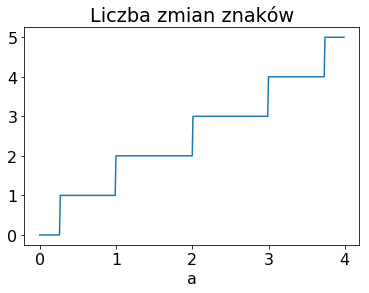

```python
# wykres liczby zmian znaków w ciągu Sturma
ta=[]
lz=[]

for a in np.arange(0,4.0,0.01):
    ta.append(a)
    lz.append(licz_zmian_znakow(a))

%matplotlib  inline
import matplotlib.pyplot as plt
plt.rcParams.update({'font.size': 16})
plt.plot(ta,lz)
plt.xlabel('a')
plt.title('Liczba zmian znaków')
plt.show()
```